# Practical Machine Learning Course: Report

## Include some libraries

```r
library(caret)
```

```r
library(ggplot2)
library(randomForest)
library(rattle)
```

## Get the Data

The data has been downloaded to the local folder. Further the two files are read

```r
train_data = read.csv("~/temp/Coursera/Prediction_Assignment/pml-training.csv")
test_data = read.csv("~/temp/Coursera/Prediction_Assignment/pml-testing.csv")
```

## Cleaning The Data

```r
filter = grep("belt|forearm|arm|dumbell|classe",names(train_data))
train = train_data[,filter]
```

Further check for any NA values

```r
sum(is.na(train))
```

```
## [1] 980016
```

```r
unique(apply(train,2,function(x) (sum(is.na(x))/length(x))*100))
```

```
## [1]  0.00000 97.93089
```

There are predictors having 97% NA values and some predictors having no NA values. It is not good idea to impute values for 97% missing data. So removing the columns having 97% missing values.

```r
train = train[,colSums(is.na(train))==0]
sum(is.na(train))
```

```
## [1] 0
```

Now all the NA values have been removed. Further removing predictors have near zero variance

```r
nzv <- nearZeroVar(train,saveMetrics = TRUE)
train <- train[,nzv$nzv==FALSE]
```

Set the test data to have the same predictor as the train set except for the outcome variable classe The last column i.e. the 40th column is the classe variable column.

```r
trainnames = colnames(train[,-40])
test <- test_data[trainnames]
```

## Partitioning The Data

Further the train data will be partitioned into a train sub set and validation sub set.

```r
set.seed(1234)
inTrain = createDataPartition(train$classe,p=0.7,list=FALSE)
mytrain = train[inTrain,]
myval = train[-inTrain,]
```

## Model Selection

The first model we check is the lda model

```r
mod_lda = train(classe~.,data=mytrain,method='lda')
pred_lda = predict(mod_lda,myval)
accuracy_lda <- confusionMatrix(pred_lda,myval$classe)$overall[[1]]
```

The accuracy is just 0.5782498. So lets try another model like the classification

```r
mod_rpart = train(classe~.,data = mytrain,method='rpart')
pred_rpart = predict(mod_rpart,myval)
accuracy_rpart <- confusionMatrix(pred_rpart,myval$classe)$overall[[1]]
```

The accuracy for this model is also 0.5330501. Further running the data for random forest Applying on the validation test for cross validation

```r
mod_rf = randomForest(classe~.,data = mytrain)
pred_rf = predict(mod_rf,myval)
accuracy_rf <- confusionMatrix(pred_rf,myval$classe)$overall[[1]]
```

Accuracy obrained is 0.9952421. So random forest gives better results than the other two models. Also the prediction matrix shows very less missclassification

```r
confusionMatrix(pred_rf,myval$classe)$table
```

```
##           Reference
## Prediction    A    B    C    D    E
##          A 1672    5    1    1    0
##          B    2 1132    3    0    0
##          C    0    2 1017    6    1
##          D    0    0    5  957    2
##          E    0    0    0    0 1079
```

Now applying this model to the actual test data

```r
pred_test_data = predict(mod_rf,test)
pred_test_data
```

```
##  1  2  3  4  5  6  7  8  9 10 11 12 13 14 15 16 17 18 19 20
##  B  A  B  A  A  E  D  B  A  A  B  C  B  A  E  E  A  B  B  B
## Levels: A B C D E
```

Just to check if stacking lda and rpart model can give better results

```r
predDF <- data.frame(pred_rpart,pred_lda,classe=myval$classe)
commodfit <- train(classe~.,method="rf",data=predDF)
compred <- predict(commodfit,predDF)
confusionMatrix(compred,predDF$classe)$overall[[1]]
```

```
## [1] 0.646729
```

Stacking improves the accuracy compared to lda and rpart algorithm indivitually. But still the random forest model gives better accuracy. The out of sample error is:

```r
1 - accuracy_rf
```

```
## [1] 0.004757859
```

## Appendix 1: Figures

The correlation matrix for the selected predictors, to check that the predictors are orthogonal.

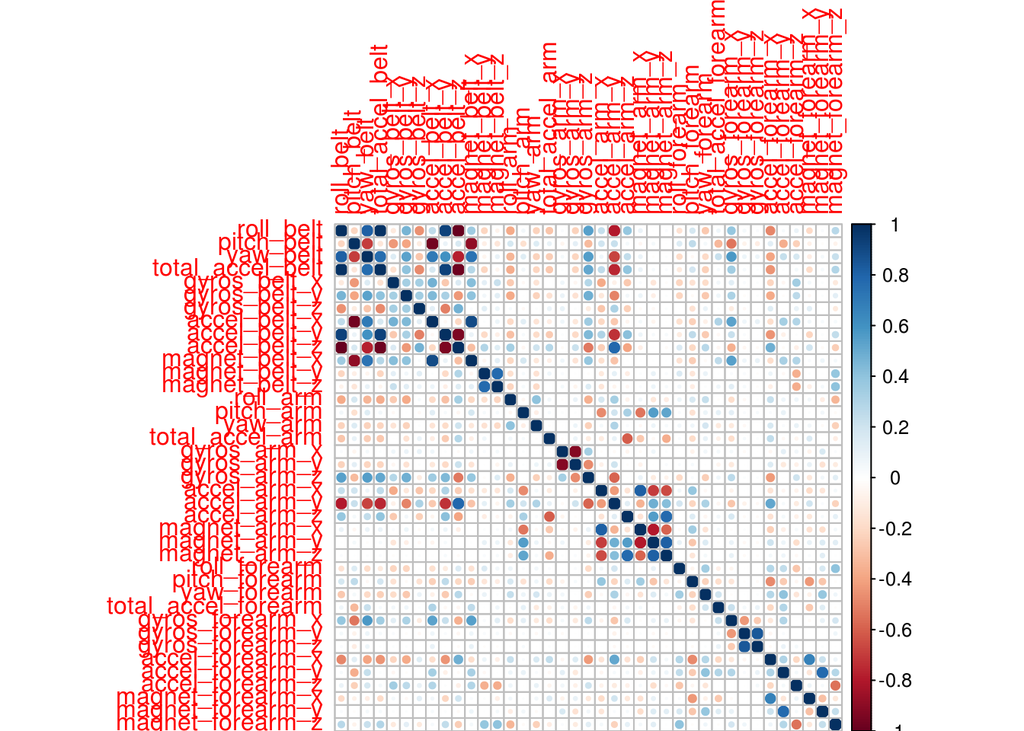

```r
corr_predictors <- cor(train[,-40])
library(corrplot)
corrplot(corr_predictors)
```

The classification tree

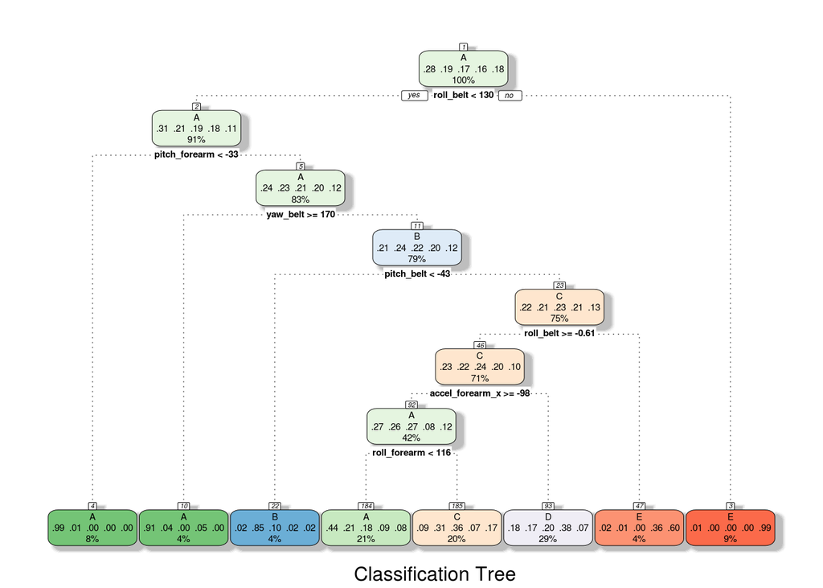

```r
library(rattle)
fancyRpartPlot(mod_rpart$finalModel,sub = "Classification Tree")
```